# Final Project

Kate Hickman

## [Home](https://kjehickman.github.io/) | [Final Project](https://kjehickman.github.io/Final_Project/Final_Project.html) | [About Me](https://kjehickman.github.io/About_Me/About_me.html)

# Bacterial-Fungal Interactions in Mangrove Roots

## **Introduction**

This project aims to illuminate potential interactions between bacterial and fungal species in terms of community assembly as a funciton of location, host plant or plant structure. The analysis is multi-faceted and will include various comparisons between the subjects of research.

# **Data Analysis**

## Bacterial and Fungal Community Data

We’re dealing with several datasets that illustrate the presence of microbial communities on Mangrove roots. Microbial communities of interest are **bacterial** and **fungal** communities by Phyla.

```r
full <- readRDS("./bact_and_fungi_clean_ps_object")

full_sam <- full@sam_data %>% as("data.frame")

full_sam %>% names
```

```
##  [1] "Host"                           "SampleID"
##  [3] "PCR_Negative"                   "Location"
##  [5] "Structure"                      "Study"
##  [7] "Run"                            "BioProject"
##  [9] "BioSample"                      "Experiment"
## [11] "geo_loc_name_country"           "geo_loc_name_country_continent"
## [13] "geo_loc_name"                   "SRAStudy"
## [15] "Fwd_Path"                       "Rev_Path"
## [17] "SampleIDList"                   "Microbe"
## [19] "GPS"                            "Lat"
## [21] "Lon"                            "IlluminaRun"
```

```r
full_sam %>%
  select(Location, Host, Structure, Microbe, Lat, Lon) %>%
  kableExtra::kable() %>%
  kableExtra::kable_classic() %>%
  kableExtra::kable_styling() %>%
  kableExtra::scroll_box(width = "500px", height = "200px")
```

|  | Location | Host | Structure | Microbe | Lat | Lon |
| --- | --- | --- | --- | --- | --- | --- |
| AA_Mer_Le_05 | Merang | Avicennia alba | Leaf | Fungi | 5.534833 | 102.94433 |
| AA_Mer_Le_06 | Merang | Avicennia alba | Leaf | Fungi | 5.534833 | 102.94433 |
| AA_Sem_So_04 | Semakau | Avicennia alba | Sediment | Fungi | 1.211727 | 103.75878 |
| AA_Sem_So_03 | Semakau | Avicennia alba | Sediment | Fungi | 1.211727 | 103.75878 |
| AA_Mer_Le_09 | Merang | Avicennia alba | Leaf | Fungi | 5.534833 | 102.94433 |
| AA_Mer_Le_10 | Merang | Avicennia alba | Leaf | Fungi | 5.534833 | 102.94433 |
| AA_Mer_Pn_01 | Merang | Avicennia alba | Pneumatophore | Fungi | 5.534833 | 102.94433 |
| AA_Sem_Fr_07 | Semakau | Avicennia alba | Fruit | Fungi | 1.211727 | 103.75878 |
| AA_Sem_Fr_06 | Semakau | Avicennia alba | Fruit | Fungi | 1.211727 | 103.75878 |
| AA_Sem_So_02 | Semakau | Avicennia alba | Sediment | Fungi | 1.211727 | 103.75878 |
| AA_Sem_So_01 | Semakau | Avicennia alba | Sediment | Fungi | 1.211727 | 103.75878 |
| AA_Kran_Fr_09 | Kranji | Avicennia alba | Fruit | Fungi | 1.438302 | 103.75288 |
| AA_Kran_Fr_01 | Kranji | Avicennia alba | Fruit | Fungi | 1.438302 | 103.75288 |
| AA_Kran_Fr_03 | Kranji | Avicennia alba | Fruit | Fungi | 1.438302 | 103.75288 |
| AA_Kran_Fr_04 | Kranji | Avicennia alba | Fruit | Fungi | 1.438302 | 103.75288 |
| AA_Kran_Fr_07 | Kranji | Avicennia alba | Fruit | Fungi | 1.438302 | 103.75288 |
| AA_LK_Pn_03 | Langkawi | Avicennia alba | Pneumatophore | Fungi | 6.456892 | 99.82261 |
| AA_LK_Fr_07 | Langkawi | Avicennia alba | Fruit | Fungi | 6.456892 | 99.82261 |
| AA_Mer_Le_04 | Merang | Avicennia alba | Leaf | Fungi | 5.534833 | 102.94433 |
| AA_Mer_Le_03 | Merang | Avicennia alba | Leaf | Fungi | 5.534833 | 102.94433 |
| AA_Mer_Le_02 | Merang | Avicennia alba | Leaf | Fungi | 5.534833 | 102.94433 |
| AA_Mer_Le_01 | Merang | Avicennia alba | Leaf | Fungi | 5.534833 | 102.94433 |
| AA_Sem_So_10 | Semakau | Avicennia alba | Sediment | Fungi | 1.211727 | 103.75878 |
| AA_Sem_So_09 | Semakau | Avicennia alba | Sediment | Fungi | 1.211727 | 103.75878 |
| AA_Sem_So_08 | Semakau | Avicennia alba | Sediment | Fungi | 1.211727 | 103.75878 |
| AA_Sem_So_07 | Semakau | Avicennia alba | Sediment | Fungi | 1.211727 | 103.75878 |
| AA_Sem_So_06 | Semakau | Avicennia alba | Sediment | Fungi | 1.211727 | 103.75878 |
| AA_Sem_So_05 | Semakau | Avicennia alba | Sediment | Fungi | 1.211727 | 103.75878 |
| AA_LK_Pn_01 | Langkawi | Avicennia alba | Pneumatophore | Fungi | 6.456892 | 99.82261 |
| AA_LK_Le_10 | Langkawi | Avicennia alba | Leaf | Fungi | 6.456892 | 99.82261 |

[output cut: 448 more lines]

```r
full_sam %>%
  select(Host, Location, Structure) %>%
  filter(Location != "Blank") %>%
  filter(Host != "Blank") %>%
  table() %>%
  as.data.frame()
```

```
##               Host     Location     Structure Freq
## 1   Avicennia alba    Chek Jawa         Fruit    9
## 2  Sonneratia alba    Chek Jawa         Fruit    1
## 3   Avicennia alba       Kranji         Fruit    6
## 4  Sonneratia alba       Kranji         Fruit    1
## 5   Avicennia alba     Langkawi         Fruit   10
## 6  Sonneratia alba     Langkawi         Fruit    1
## 7   Avicennia alba Lim Chu Kang         Fruit    9
## 8  Sonneratia alba Lim Chu Kang         Fruit    2
## 9   Avicennia alba       Merang         Fruit   10
## 10 Sonneratia alba       Merang         Fruit    0
## 11  Avicennia alba Port Dickson         Fruit    0
## 12 Sonneratia alba Port Dickson         Fruit    3
## 13  Avicennia alba       Redang         Fruit    0
## 14 Sonneratia alba       Redang         Fruit    5
```

[output cut: 66 more lines]

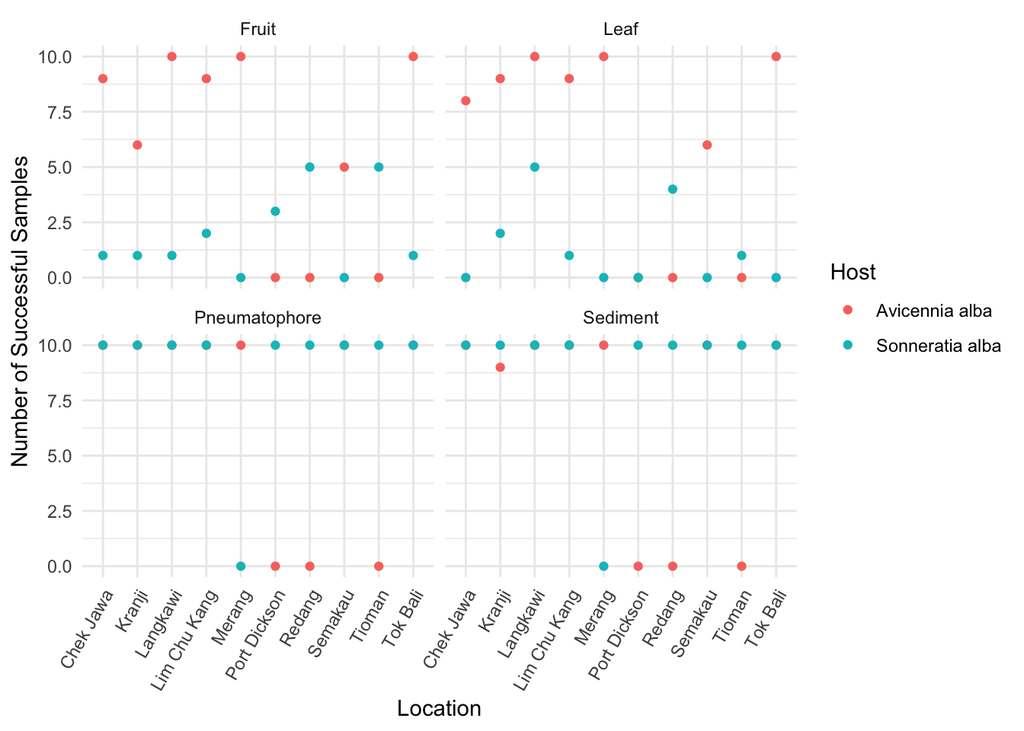

```r
full_sam %>%
  select(Host, Location, Structure) %>%
  filter(Location != "Blank") %>%
  filter(Host != "Blank") %>%
  table() %>%
  as.data.frame() %>%
  ggplot(aes(x=Location, y=Freq, color=Host)) +
  geom_point() +
  facet_wrap(~Structure) +
  labs(y = "Number of Successful Samples") +
  theme_minimal() +
  theme(axis.text.x = element_text(angle = 60, hjust = 1))
```

Now that we can see the observed parameters, can can begin to ask questions about the data. For the purposes of this analysis, we’ll be focusing on Structure, Microbe, Lat and Long.

THE FINAL PLOT AND TABLE ARE BASED OFF OF INCONSISTENCIES IN SAMPLE RUNS. You can’t make direct comparison of samples between hosts in some locations (Merang, Redang, etc.). The testing must have preferred sediment over fruit, since consistency. There’s a caveat for several locations on our claims where data isn’t there for every host: this could be due to lost or damaged samples, absence of host (Sonneratia on Merang), poor sequence data or bioinformatic analysis (based on confidence intervals).

It may also be useful to understand what taxonomic groups are present in our samples.